# Презентация по лабораторной №6

Основы интерфейса взаимодействия пользователя с системой Unix на уровне командной строки

Виноградова М.А

Российский университет дружбы народов, Москва, Россия

22 марта 2025

# Информация

## Докладчик

- Виноградова Мария Андреевна
- студентка НПИбд-01-24
- номер студ. билета 1132240691
- Российский университет дружбы народов
- 1132240691@pfur.ru
- https://github.com/mavinogradova/study_2024-2025_os-intro

## Цель работы

Приобретение практических навыков взаимодействия пользователя с системой по-средством командной строки.

# Выполнение лабораторной работы

## Выведите на экран содержимое каталога /tmp. Для этого используйте команду ls с различными опциями.

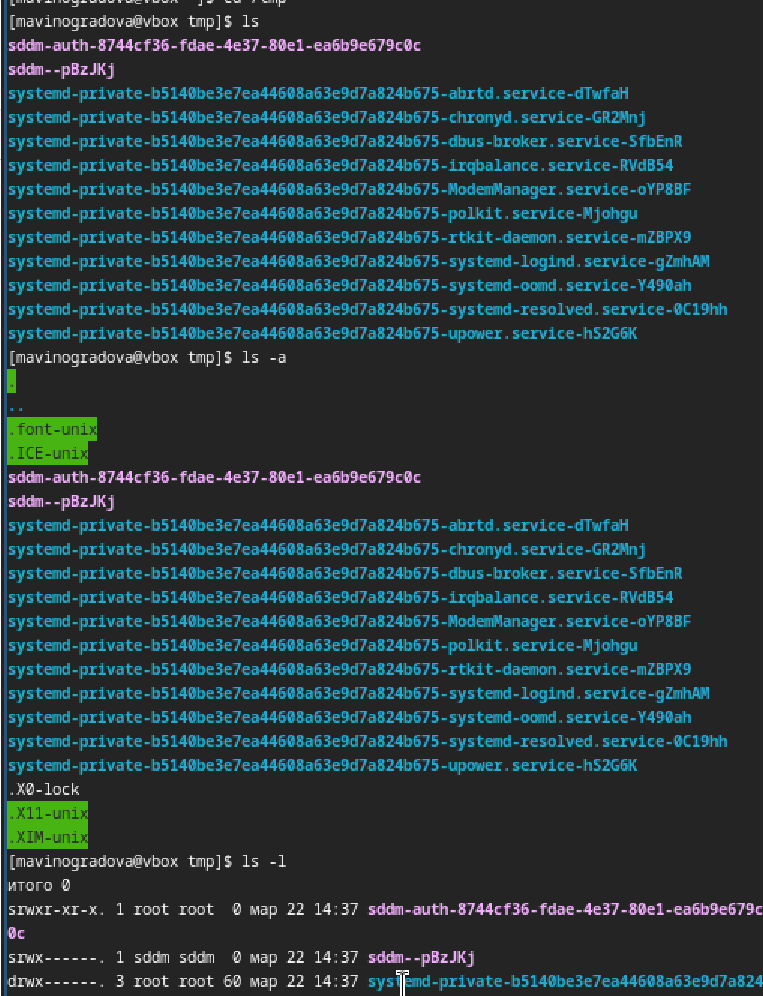

Опции ls

## Определите, есть ли в каталоге /var/spool подкаталог с именем cron.

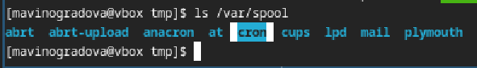

Ищем подкаталог

## Перейдите в Ваш домашний каталог и выведите на экран его содержимое

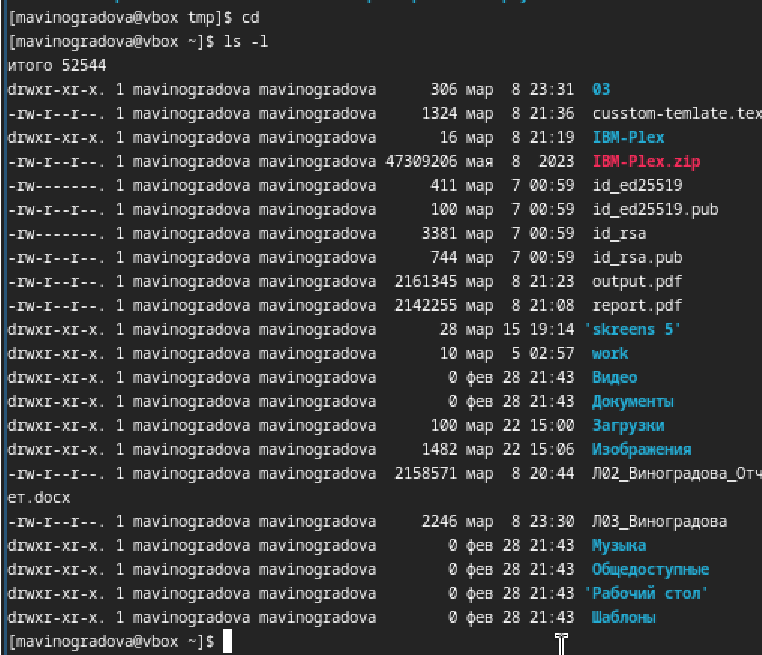

Переходим в домашний каталог

## В домашнем каталоге создайте новый каталог с именем newdir.

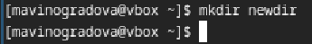

Создаем новый каталог в домашнем каталоге

## В каталоге ~/newdir создайте новый каталог с именем morefun.

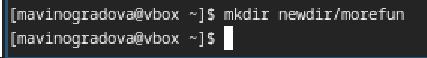

Создаем новый каталог в созданном ранее каталоге

## В домашнем каталоге создайте одной командой три новых каталога с именами letters, memos, misk.

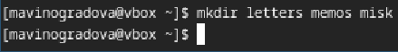

Создаем три каталога одной командой

## Затем удалите эти каталоги одной командой.

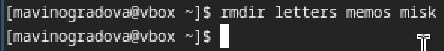

Удаляем созданные каталоги одной командой

## Попробуйте удалить ранее созданный каталог ~/newdir командой rm.

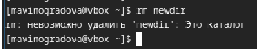

Пробуем удалить ранее созданный каталог

## Удалите каталог ~/newdir/morefun из домашнего каталога.

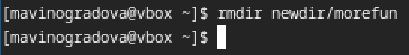

Удаляем каталог из домашнего каталога

## С помощью команды man определите, какую опцию команды ls нужно использовать для просмотра содержимое не только указанного каталога, но и подкаталогов, входящих в него.

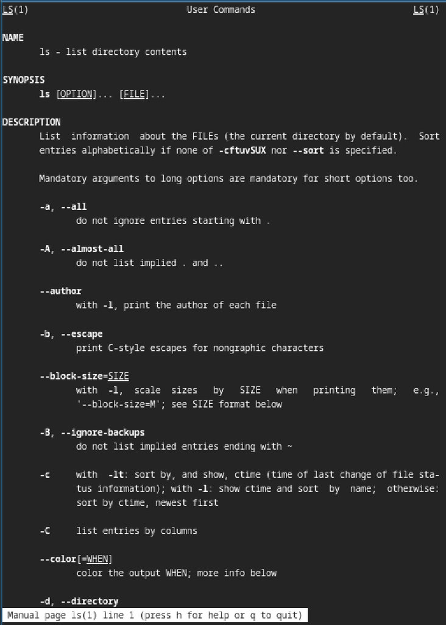

С помощью команды определяем необходимую опцию

## Проверяем правильность определенной ранее опции.

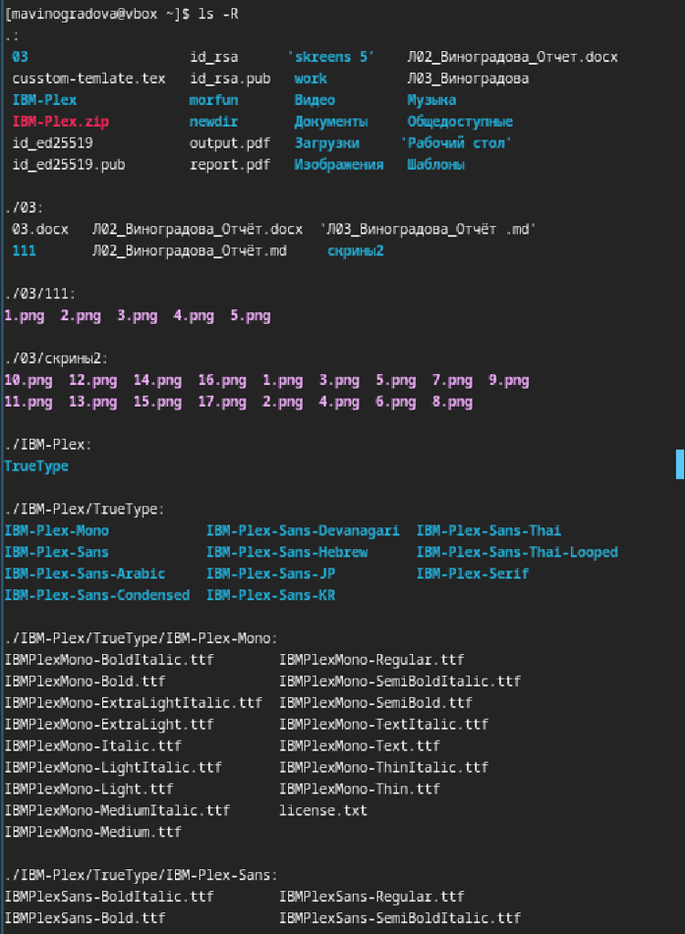

Выводим на экран информацию

## С помощью команды man определите набор опций команды ls, позволяющий отсортировать по времени последнего изменения выводимый список содержимого каталога с развёрнутым описанием файлов.

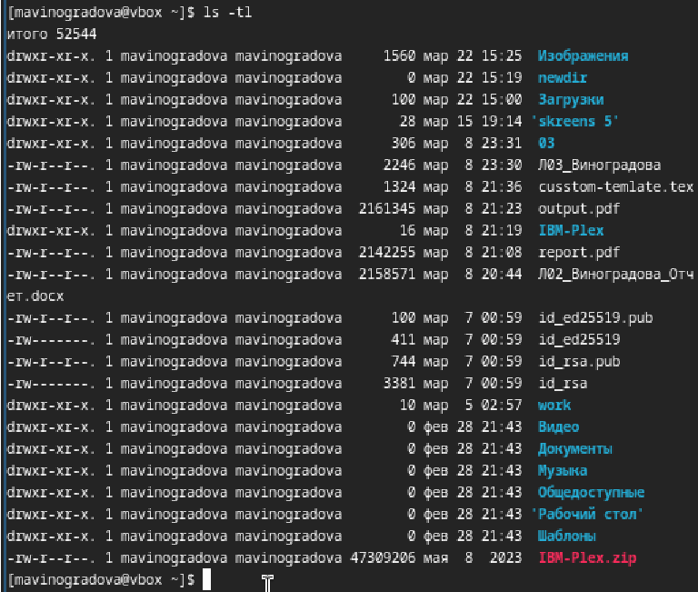

Выводим на экран информацию

## Используйте команду man для просмотра описания следующих команд: cd, pwd, mkdir,rmdir, rm.

### cd

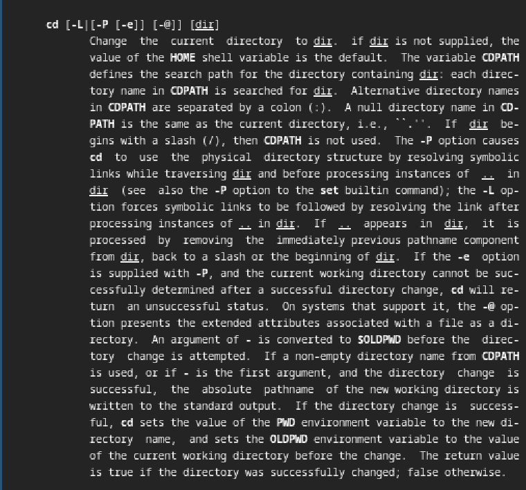

Выводим описание

### pwd

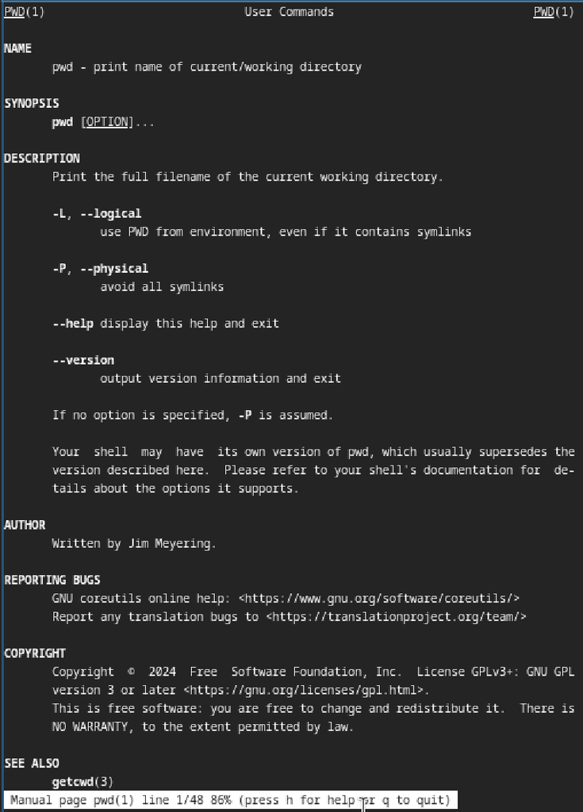

Выводим описание

### mkdir

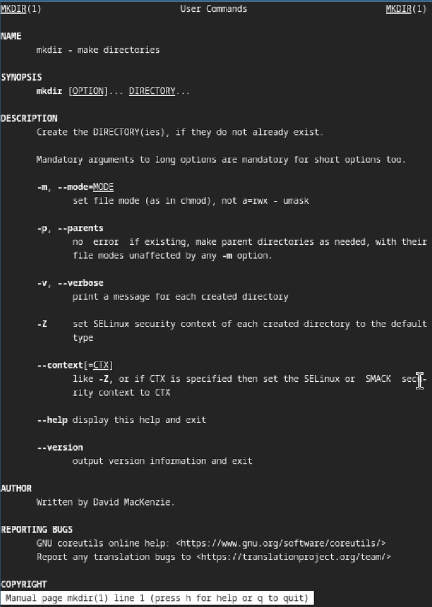

Выводим описание

### rmdir

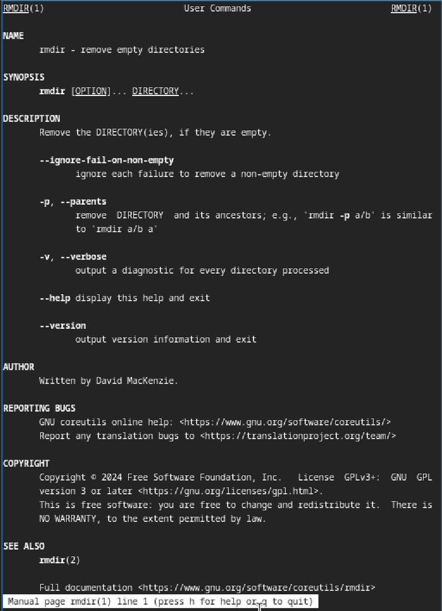

Выводим описание

### rm

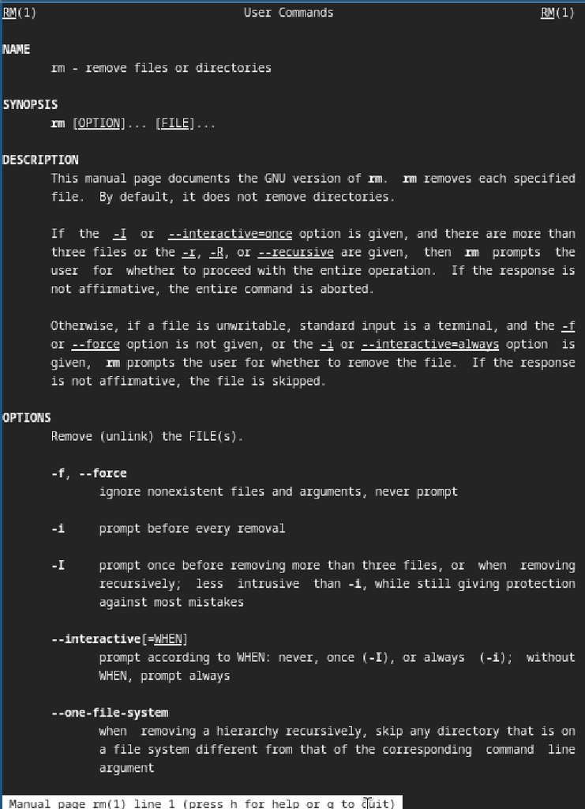

Выводим описание

## Используя информацию, полученную при помощи команды history, выполните модификацию и исполнение нескольких команд из буфера команд.

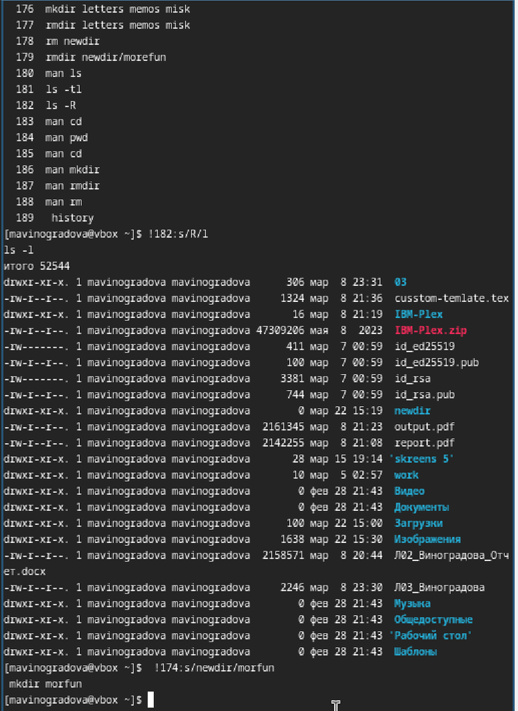